# Wohnungsmigration in München

31.03.2026 | Betreuerin: Christina Sauer

Heinz Calderón, Christian Lex, Dennis Ley, Haoyang Yang

## Fragen unserer Analyse

1. Entwicklung der Zuzüge der 25 Münchner Stadtbezirke (Deutsch vs. Nichtdeutsch)
2. Entwicklung der Wegzüge der 25 Münchner Stadtbezirke (Innen vs. Außen)
3. Entwicklung der Bevölkerungsdichte  
   (Einwohner pro $km^2$)

## Agenda

1. Datenüberblick
2. Datenanalyse
   - Zuzüge
   - Wegzüge
   - Bevölkerungsentwicklung
3. Zusammenfassung und Ausblick

## Datenüberblick

Datensatz (gejoint und vereinfacht)

[output not shown]

## Datenüberblick

Wanderungsmatrix (pro Jahr)

| von/nach | Bezirk 1 | Bezirk 2 | … | Bezirk 25 |
| --- | --- | --- | --- | --- |
| Bezirk 1 | 262 | 179 | … | 47 |
| Bezirk 2 | 145 | 1078 | … | 162 |
| … | … | … | … | … |
| Bezirk 25 | 47 | 162 | … | 3825 |

Zeitraum: 2005–2024

## Datenüberblick

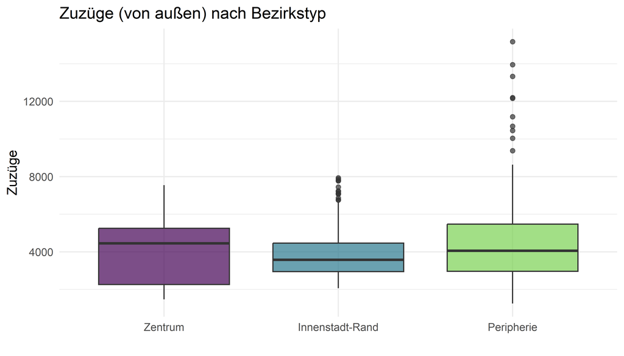

## Datenüberblick

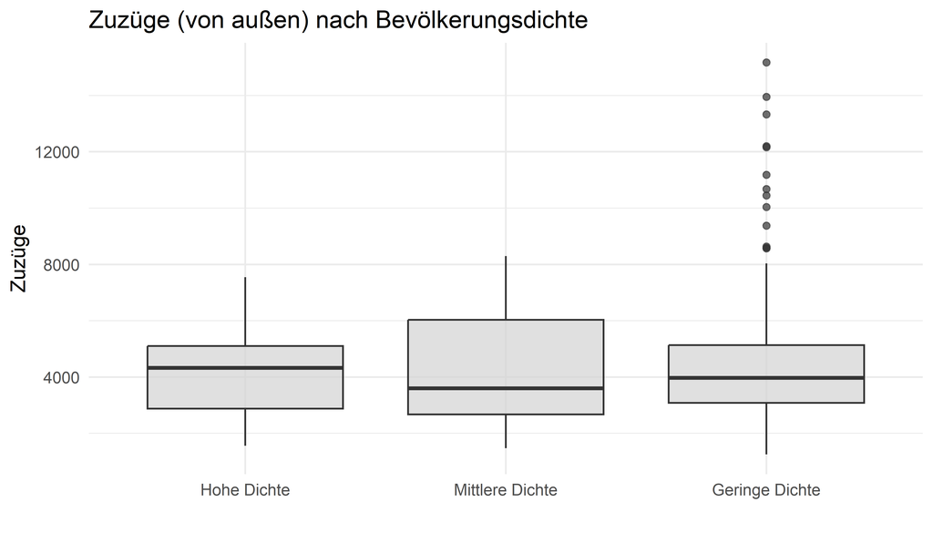

## Datenüberblick

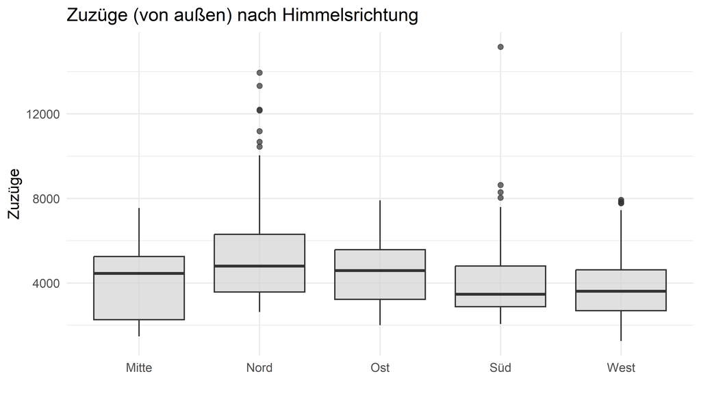

## Datenüberblick

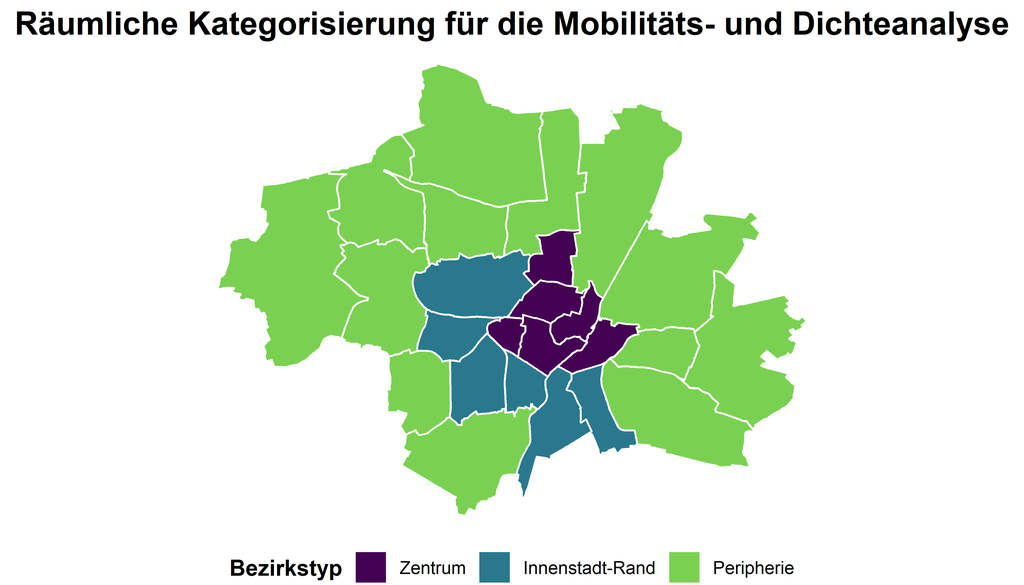

## Agenda

1. Datenüberblick
2. **Datenanalyse**
   - Zuzüge
   - Wegzüge
   - Bevölkerungsentwicklung
3. Zusammenfassung und Ausblick

## Zuzüge (von außen)

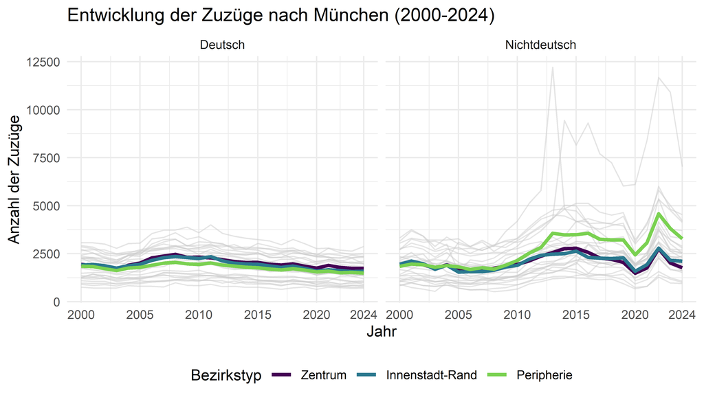

## Zuzüge (von außen)

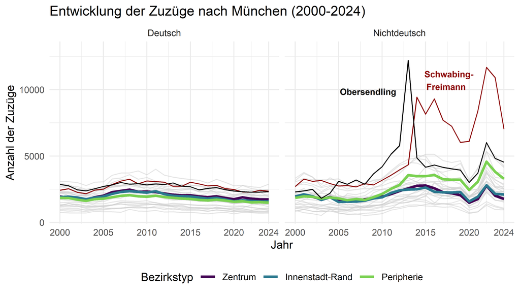

## Zuzüge (innerhalb)

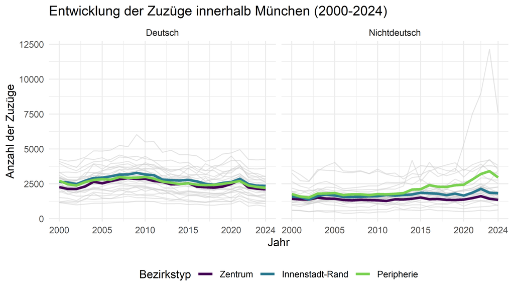

## Zuzüge (innerhalb)

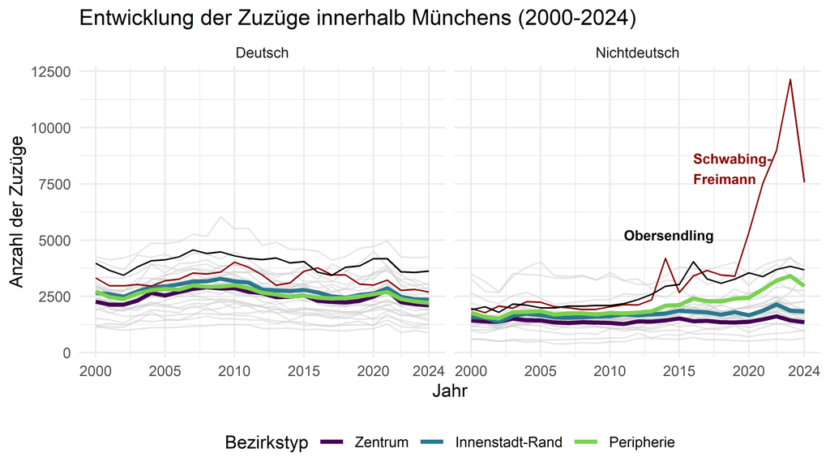

## Agenda

1. Datenüberblick
2. **Datenanalyse**
   - Zuzüge
   - Wegzüge
   - Bevölkerungsentwicklung
3. Zusammenfassung und Ausblick

## Wegzüge

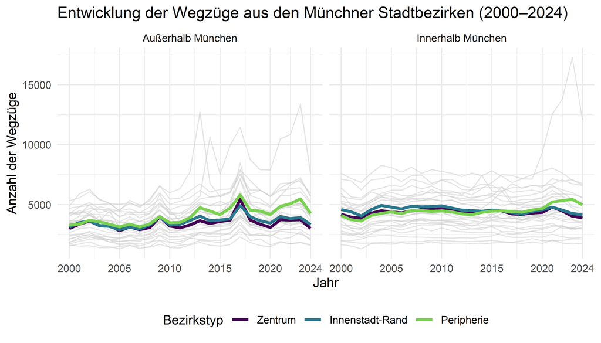

## Wegzüge

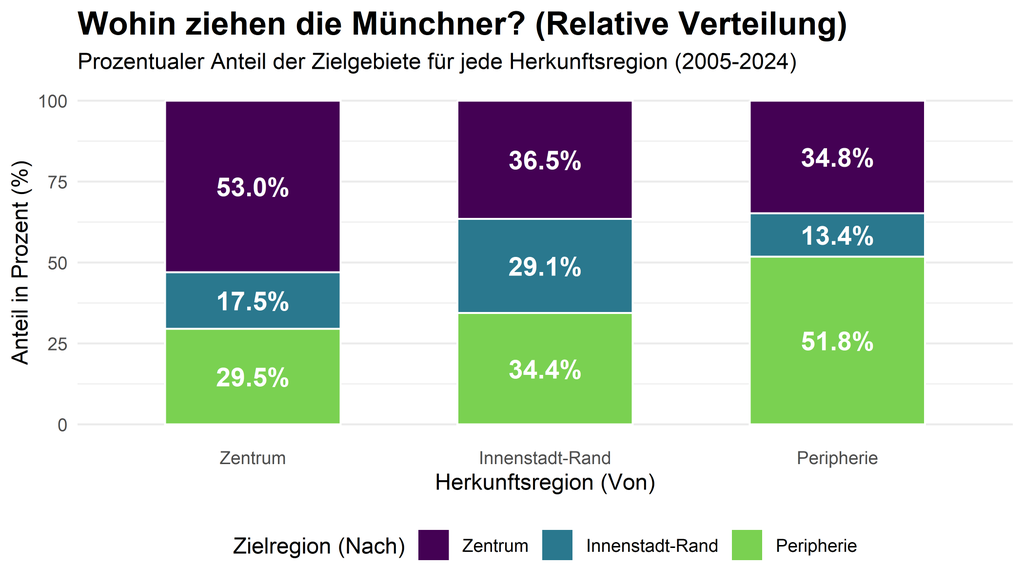

## Agenda

1. Datenüberblick
2. **Datenanalyse**
   - Zuzüge
   - Wegzüge
   - Bevölkerungsentwicklung
3. Zusammenfassung und Ausblick

## Bevölkerungsentwicklung

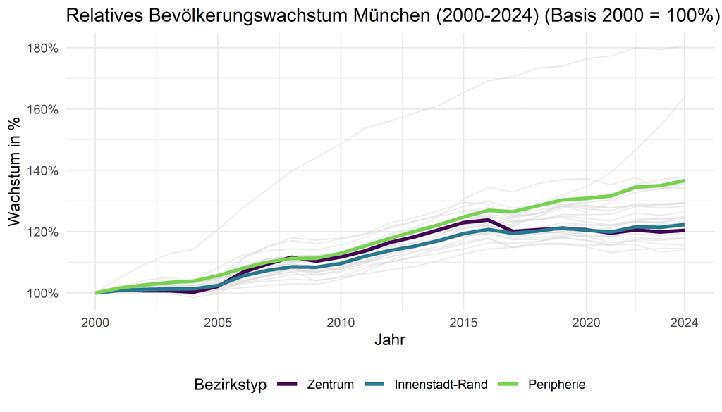

## Bevölkerungsentwicklung

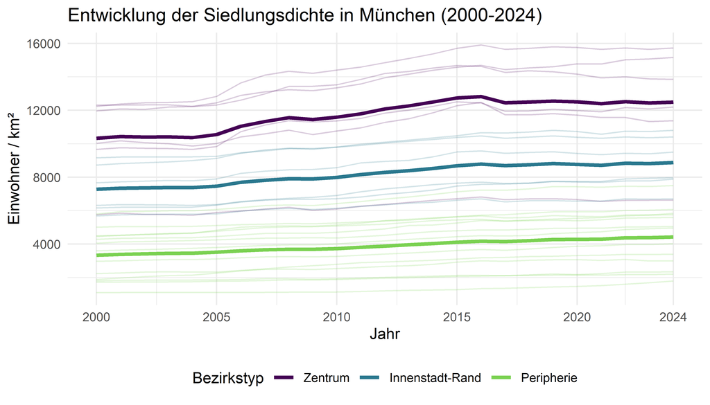

## Bevölkerungsentwicklung

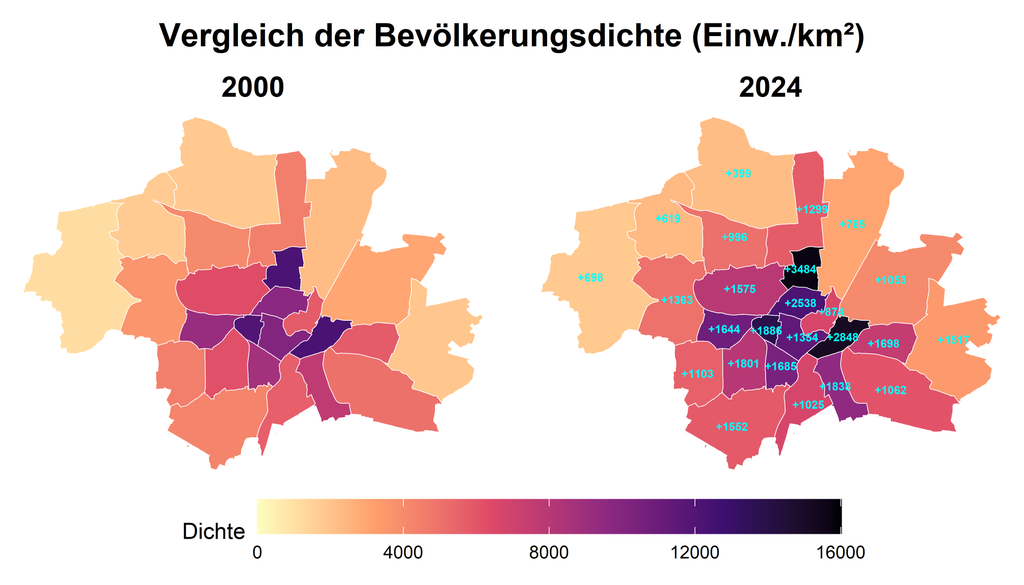

## Agenda

1. Datenüberblick
2. Datenanalyse
   - Zuzüge
   - Wegzüge
   - Bevölkerungsentwicklung
3. **Zusammenfassung und Ausblick**

## Zusammenfassung

**Limitation**: Datensatz ab Jahr 2000 vs Wanderungsmatrizen ab 2005

1. Entwicklung der Zuzüge der 25 Münchner Stadtbezirke (Deutsch vs. Nichtdeutsch)
2. Entwicklung der Wegzüge der 25 Münchner Stadtbezirke (Innen vs. Außen)
3. Entwicklung der Bevölkerungsdichte  
   (Einwohner pro $km^2$)

## Zusammenfassung

1. **Deutsch**: Stabil, insgesamt leichter Abwärtstrend  
   **Nichtdeutsch**: hohe Volatilität, insgesamt leichter Aufwärtstrend
2. **Insgesamt** stetige Abwanderung bei Peripherie, Stagnation bei Zentrum und Innenstadt-Rand Innenstadt-Rand haben sich **relativ gleichmäßig verteilt**, aber Zentrum und Peripherie **bleiben ca. zur Hälfte im Bezirk**
3. **Insgesamt** flächendeckender Anstieg der Einwohner pro $km^2$

## Ausblick

Aktuelle Projekte zu Bevölkerungsentwicklung:

- **Freiham**: neuer Stadtteil für über 25.000 Menschen
- **Neufreimann**: 5.500 Wohnungen für 15.000 Menschen
- **Münchener Nordosten**: ab 2030 neues Zukunftsquartier für bis zu 30.000 Menschen

**Herausforderungen**: Trotz dieser Bemühungen ist der Immobilienmarkt sehr angespannt. **Steigende Baukosten**, **hohe Zinsen**, **komplizierte Vorschriften** und **Fachkräftemangel** führen zu langsame Umsetzung.

Quelle: [muenchen.de](https://stadt.muenchen.de/rathaus/projekte/stadtplanung.html), [BZS](https://www.bayerische-staatszeitung.de/staatszeitung/bauen/detailansicht-bauen/artikel/16-900-wohnungen-fehlen.html#topPosition)

## Anhang

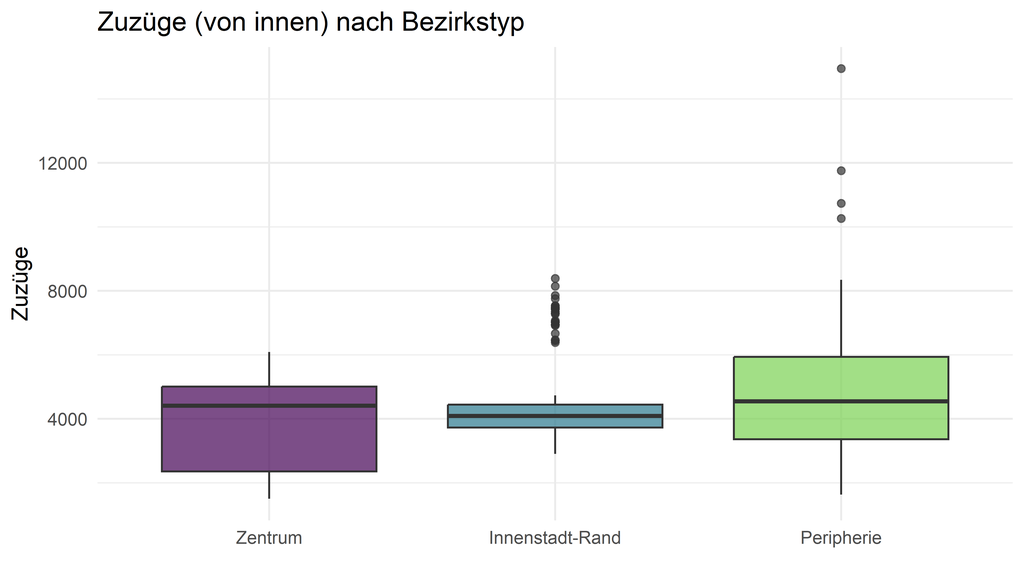

## Anhang

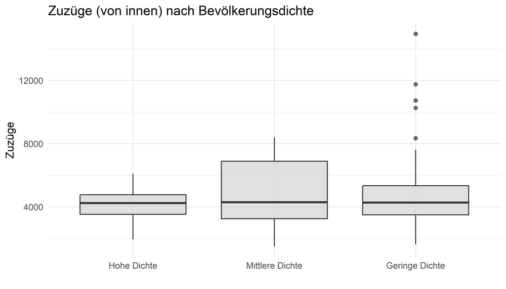

## Anhang

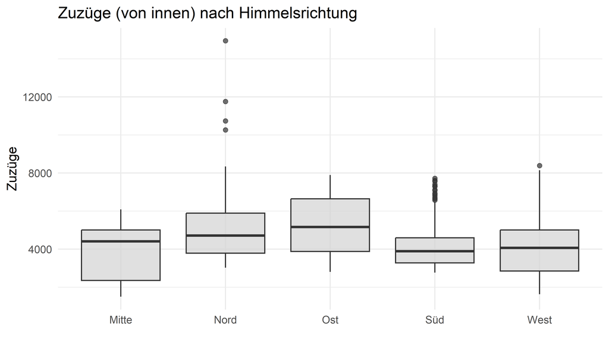

## Anhang

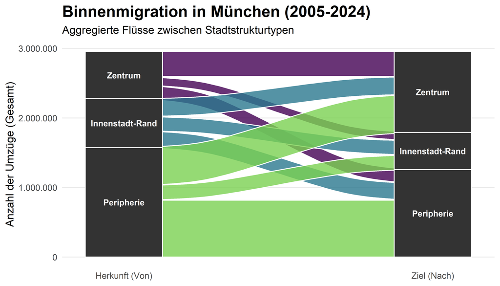

## Anhang

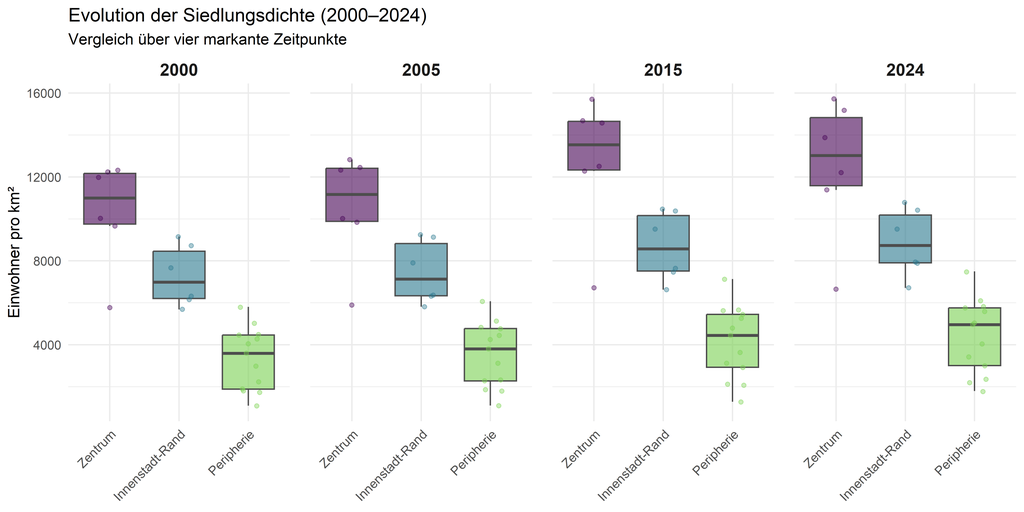